# Super Mario Kart

## Tidy Tuesday

This is my sixth contribution to TidyTuesday, which is ‘a weekly podcast and community activity brought to you by the R4DS Online Learning Community’. Their goal is to help R learners learn in real-world contexts.

For more information, visit the [TidyTuesday homepage](https://www.tidytuesday.com/), check out their [GitHub repository](https://github.com/rfordatascience/tidytuesday) and follow the [R4DS Learning Community on Twitter](https://twitter.com/R4DScommunity).

The purpose of these posts is mainly for exercising purposes. Thus, the provided graphs are not necessarily designed to provide the greatest possible insights. However, I always provide the R code for interested people at the page bottom.

## Super Mario Kart

This week’s data comes from [Mario Kart World Records](https://mkwrs.com/). It contains world records for the corresponding racing game for the Nintendo 64 gaming console.

### Convergence of record times towards their global best

When first regarding the data, I find that more interesting than the absolute record times on the tracks are the relative improvements that have been made on the tracks, and thus, how much more room for improvement there’s probably left. Again, the approach chosen by me is likely to be not the best possible, but the one I find interesting when regarding the data.

```r
# filter time w/o shortcuts
records <- records %>%
  filter(shortcut == "No") %>%
  filter(system_played == "PAL") %>%
  filter(type == "Three Lap") %>%
  mutate(image = "_images/cut.png")
# get minimum time for each track
mins <- aggregate(records$time ~ records$track, FUN = min)
names(mins) <- c("track", "time")
# divide time by minimum time
tracks <- unique(records$track)
for (i in 1:length(unique(records$track))) {
  records$time[records$track == tracks[i]] <-
    records$time[records$track == tracks[i]] / mins$time[mins$track == tracks[i]]
}
```

Then, I plot the records on all tracks:

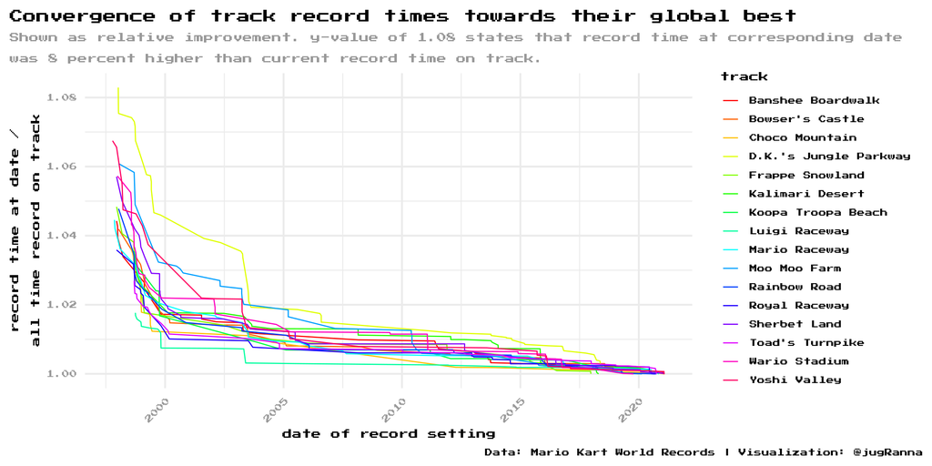

*Note:* The font and colors are chosen to match the topic, not to be most suitable for interpretation.

The tracks in the plot above are hard to distinguish. Thus, I choose to further provide a facet wrap plot which makes the tracks’ records easier to distinguish:

[figure not shown]

It is apparant that record times on some tracks, like DK’s Jungle Parkway, Yoshi Valley, or Wario Stadium improved quite substantially, while other times only got beat by rather small relative margins. Also, for most tracks, the rate of improvement seems to decline, which is of course not surprising. However, some tracks’ records definitely seem to provide more room for improvement than others.

## References

- `ggtext`**-package**:  
  https://wilkelab.org/ggtext/
- `patchwork`**-package**:  
  https://patchwork.data-imaginist.com/articles/patchwork.html
- `Rokemon`**-package**:  
  https://github.com/schochastics/rokemon
- `showtext`**-package**:  
  https://github.com/yixuan/showtext
- `tidyverse`**-package**:  
  https://www.tidyverse.org/

Full R code available on [Github](https://github.com/jgranna/tidytuesday/tree/main/2021-05-25).